# AQUASCOPE

## Who lives in Greifensee?

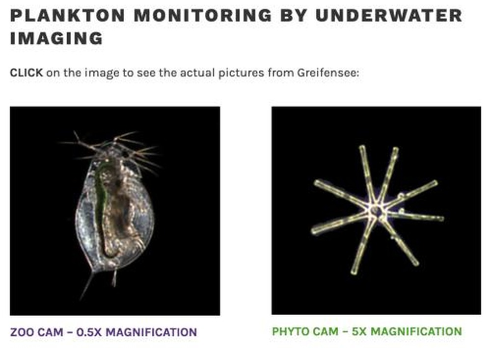

[aquascope.ch/latest-data](https://aquascope.ch/latest-data/)

## Camera specifications

|  | 5.0x | 0.5x |
| --- | --- | --- |
| Size range | 10–150 µm | 100 µm – 1 cm |
| Volume per frame | 0.2–10 µL | 4–200 µL |
| Target | Phytoplankton | Zooplankton |
| Max frame rate | 10 per second |  |
| Antifouling | UV lamp, static |  |

Merz et al. 2021

## Camera vs microscopy

0.96

R² body size

0.89

R² phytoplankton density

0.73

R² zooplankton density

Richness slightly underestimated

Merz et al. 2021 · laboratory calibration and field comparison

## Why imaging, not nets?

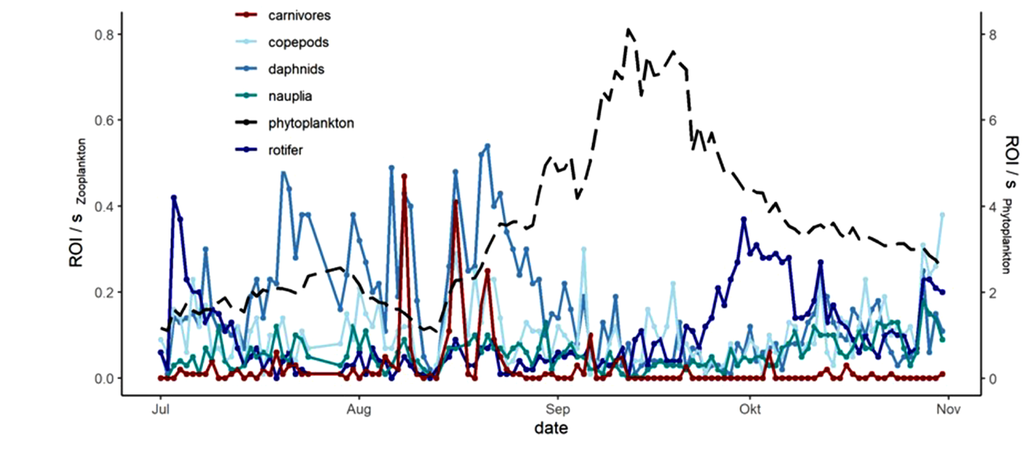

Hourly resolution

Undisturbed aggregates

Merz et al. 2021, Fig. 7

## Classifier details

35

Classes

17,900+

Annotated images

98%

Accuracy

93%

F1 score

Transfer learning + ensembling

Kyathanahally et al. 2021

## Field performance drop

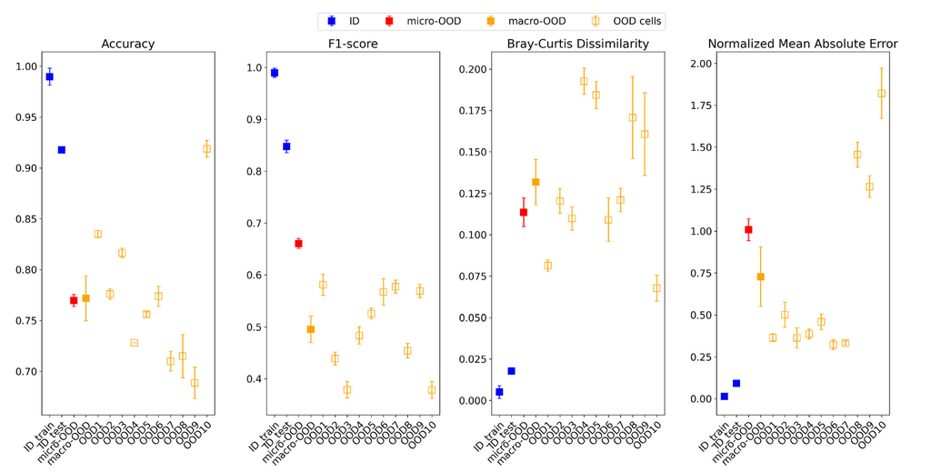

92%

Test accuracy

77%

New days

83%

Robust ensemble

Test scores overstate field performance; errors propagate into abundances

Chen et al. 2025, L&O Methods 23, 39–66, Fig. 5 (MobileNet; ID = test set, OOD = new deployment days). Ensemble: BEsT model

## Dataset shift

| Shift | Meaning |
| --- | --- |
| Prior probability | Taxon abundances change |
| Concept | Appearance changes |
| Causes | Turbidity, fouling, traits |
| Fixes | Test cells, ensembles |

Chen et al. 2025

## Correcting counts

Raw counts

➜

Confusion matrix

➜

Adjusted counts

Quantification, not classification

Chen et al. 2025 (adjusted count quantification)

## Gap handling options

| Gap | Option |
| --- | --- |
| Short | Interpolate |
| Medium | Skip affected vectors |
| Long | Split series |
| Any | Report sensitivity |

## VS-EDM performance

| Rotifers (R²) | Mean |
| --- | --- |
| Linear interpolation | 0.59 |
| Exclusion | 0.57 |
| Piecewise constant | 0.60 |
| VS-EDM | **0.68** |

Best: many gaps

Worse: short, smooth

Aphids: 50% missing

Gaps change method rankings

Johnson & Munch 2022, Table 2 and Fig. 3 (one-step-ahead forecasts)

## EDM toolbox

| Method | Use |
| --- | --- |
| Simplex projection | Forecasting, embedding choice |
| S-map | Local linear interactions |
| Regularised S-map | Noisy, many variables |
| Convergent cross mapping | Causal signal |

Sugihara et al. 2012; Cenci et al. 2019; Chang et al. 2021

## Choosing parameters

Embedding dimension E

Locality θ

Regularisation λ

Cross-validated skill

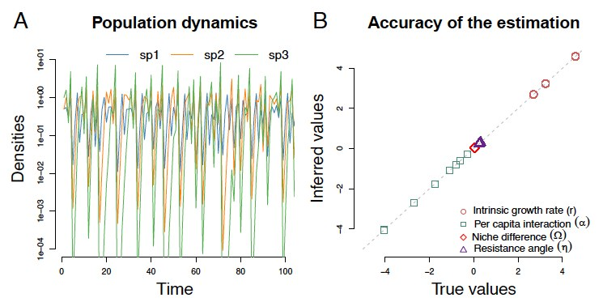

Out-of-sample decides

Simulation test: Nguyen, Pomati & Rohr 2025

## Measuring forecast skill

| Metric | Reads as |
| --- | --- |
| Correlation ρ | Pattern match |
| RMSE | Error size |
| Persistence model | Baseline to beat |
| Horizon | Days ahead |

Merz et al. 2025

## Caveats

| Limit | Consequence |
| --- | --- |
| Short series | Wide uncertainty |
| Observational data | Not causal proof |
| Realised interactions | Context dependent |
| Image-based taxa | Genus-level resolution |

## Trait-based view

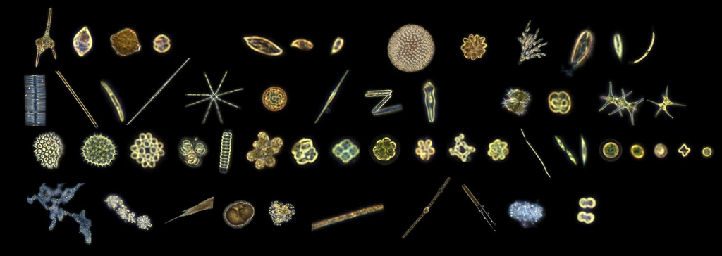

Six size classes

Temperature key

Grazing: small cells

Nutrients: extremes

Eyring et al. 2025, ISME Commun. 5, ycae148 (Random Forest, six size classes)

## Interactions shift niches

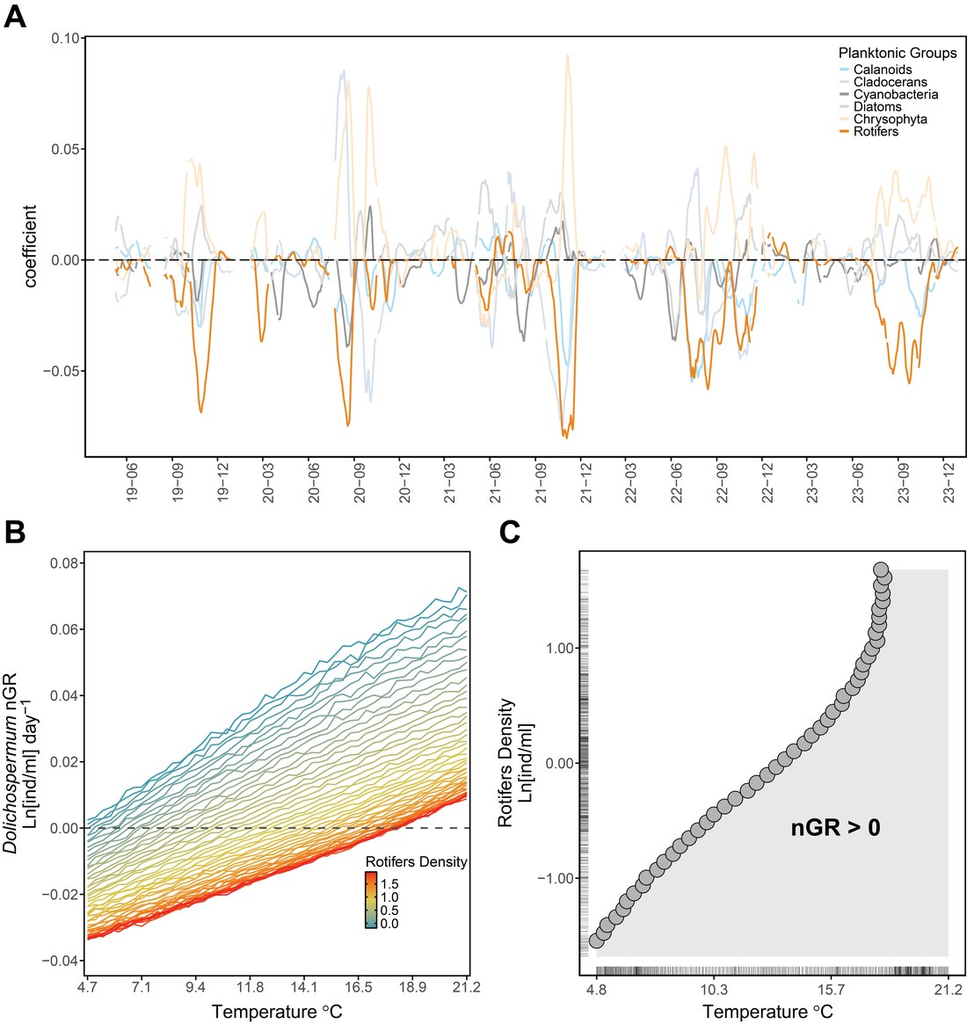

Ntetsika et al. 2025, bioRxiv 10.1101/2025.04.16.649070

## Open data and code

| Resource | Where |
| --- | --- |
| Time series data | opendata.eawag.ch |
| Live dashboards | datalakes-eawag.ch |
| Classifier code | github.com/mbaityje/plankifier |
| Annotation tool | taxonify.org |
| Greifensee dataset | doi 10.1038/s41597-025-04988-9 |

## References (1/2)

- Cenci, S., Sugihara, G. & Saavedra, S. (2019). [Regularized S-map for inference and forecasting with noisy ecological time series](https://doi.org/10.1111/2041-210X.13117). *Methods in Ecology and Evolution*, 10, 650–660.
- Chang, C.-W., Ushio, M. & Hsieh, C. (2017). Empirical dynamic modeling for beginners. *Ecological Research*, 32, 785–796.
- Chang, C.-W. *et al.* (2021). Reconstructing large interaction networks from empirical time series data. *Ecology Letters*, 24, 2763–2774.
- Chen, C., Kyathanahally, S.P., Reyes, M., Merkli, S., Merz, E., Francazi, E., Hoege, M., Pomati, F. & Baity-Jesi, M. (2025). [Producing plankton classifiers that are robust to dataset shift](https://doi.org/10.1002/lom3.10659). *Limnology & Oceanography: Methods*, 23, 39–66.
- Eyring, S. *et al.* (2025). [Five years of high-frequency data of phytoplankton, zooplankton and limnology from a temperate eutrophic lake](https://doi.org/10.1038/s41597-025-04988-9). *Scientific Data*, 12, 653.
- Eyring, S., Merz, E., Reyes, M., Ntetsika, P., Dennis, S.R., Isles, P.D.F., *et al.* (2025). [Distinct phytoplankton size classes respond differently to biotic and abiotic factors](https://doi.org/10.1093/ismeco/ycae148). *ISME Communications*, 5, ycae148.
- Johnson, B. & Munch, S.B. (2022). [An empirical dynamic modeling framework for missing or irregular samples](https://doi.org/10.1016/j.ecolmodel.2022.109948). *Ecological Modelling*, 468, 109948.
- Kyathanahally, S.P., Hardeman, T., Merz, E., Bulas, T., Reyes, M., Isles, P., Pomati, F. & Baity-Jesi, M. (2021). [Deep learning classification of lake zooplankton](https://doi.org/10.3389/fmicb.2021.746297). *Frontiers in Microbiology*, 12, 746297.
- Merz, E., Kozakiewicz, T., Reyes, M., Ebi, C., Isles, P., Baity-Jesi, M., *et al.* (2021). [Underwater dual-magnification imaging for automated lake plankton monitoring](https://doi.org/10.1016/j.watres.2021.117524). *Water Research*, 203, 117524.

## References (2/2)

- Merz, E., Pomati, F., Saavedra, S. & Gilarranz, L.J. (2025). [Biodiversity forecasting in natural plankton communities reveals temperature and biotic interactions as key predictors](https://doi.org/10.1098/rspb.2024.2895). *Proceedings of the Royal Society B*, 292.
- Nguyen, P.L., Pomati, F. & Rohr, R.P. (2025). [Inferring coexistence likelihood in changing environments from ecological time series](https://doi.org/10.1073/pnas.2417905122). *PNAS*, 122, e2417905122.
- Ntetsika, P. *et al.* (2025). [Biotic interactions shape the realised niche of toxic cyanobacteria](https://doi.org/10.1101/2025.04.16.649070). *bioRxiv*, 2025.04.16.649070.
- Orenstein, E.C. *et al.* (2020). The Scripps Plankton Camera system: a framework and platform for in situ microscopy. *Limnology & Oceanography: Methods*, 18, 681–695.
- Stark, J. (1999). Delay embeddings for forced systems. I. Deterministic forcing. *Journal of Nonlinear Science*, 9, 255–332.
- Stark, J., Broomhead, D.S., Davies, M.E. & Huke, J. (1997). Takens embedding theorems for forced and stochastic systems. *Nonlinear Analysis: Theory, Methods & Applications*, 30, 5303–5314.
- Deyle, E.R., Maher, M.C., Hernandez, R.D., Basu, S. & Sugihara, G. (2016). Global environmental drivers of influenza. *PNAS*, 113, 13081–13086.
- Rogers, T.L. & Munch, S.B. (2020). Hidden similarities in the dynamics of a weakly synchronous marine metapopulation. *PNAS*, 117, 479–485.
- Brias, A. & Munch, S.B. (2021). Ecosystem based multi-species management using empirical dynamic programming. *Ecological Modelling*, 441, 109423.
- Sugihara, G. (1994). Nonlinear forecasting for the classification of natural time series. *Philosophical Transactions of the Royal Society A*, 348, 477–495.
- Sugihara, G. & May, R.M. (1990). Nonlinear forecasting as a way of distinguishing chaos from measurement error in time series. *Nature*, 344, 734–741.
- Sugihara, G., May, R., Ye, H., Hsieh, C.-H., Deyle, E., Fogarty, M. & Munch, S. (2012). Detecting causality in complex ecosystems. *Science*, 338, 496–500.
- Takens, F. (1981). Detecting strange attractors in turbulence. *Lecture Notes in Mathematics*, 898, 366–381.